# Final Project Report

Ben & Zheling

[figure not shown]

(Nobles, n.d.)

### 1. Introduction

#### a.

> The set of data sets we used are called, “Mario Kart 64 World Records” from tidytuesday on GitHub’s website under rfordatascience. Mario Kart 64 was a popular racing game on Nintendo 64, released back in 1996, 1997 in North America, and is still actively played today. The data was collected from Mario Kart World Records where people can post their times and videos of their records. This is not officially affiliated with Nintendo and since there are so many Mario Kart games now, there are different teams dedicated to managing records for the different games.

> There are two data sets in the Mario Kart 64 World Records data set, world-records (which we’ll call records) and drivers. Records has 10 variables and 2,334 cases. Each case is a record that was set, and the variables are track name, whether it was a single lap or full race record, whether a shortcut was used, the player’s name, the system it was played on, the date the record was set, the time in two formats and the number of days the record stood.

> The drivers data set has 6 variables and 2,250 cases. Each case are the top record holders for that year, top 90 for each year.The variables include the player’s current leader board position, the player’s name, the total world records they hold, the year, the number of world records they obtained that year and player’s nationality.

> Further note about records data set: Mario Kart 64 has 16 tracks, and the records data set includes track records for single laps and the complete races, three laps. Whether players used shortcuts in their record time is also included, this was yes or no and does not include glitches. There are a whole host of rules that dictate what is an official submission (Mario Kart 64 Players’ Page, n.d.-a) but essentially you must play the game the way it was intended to be played. Another variable included is what system the lap was set on, National Television System Committee (NTSC) and Phase Alternating Line (PAL). These systems were used in different countries and run at different frames per second, NTSC being higher than PAL, but the Mario Kart 64 Player’s page offers a conversion so lap times should essentially be the same on either system (Mario Kart 64 Players’ Page, n.d.-b).

#### b. Questions of interest.

#### 1) What do the overall trends of the records?

#### 2) What are the current track records?

#### 3) How much has the time improved for each track?

#### 4) How much time were the longest held records beat by?

### 2. Results

#### This data visualization was created to answer our first question, “What are the overall trends of the records?”

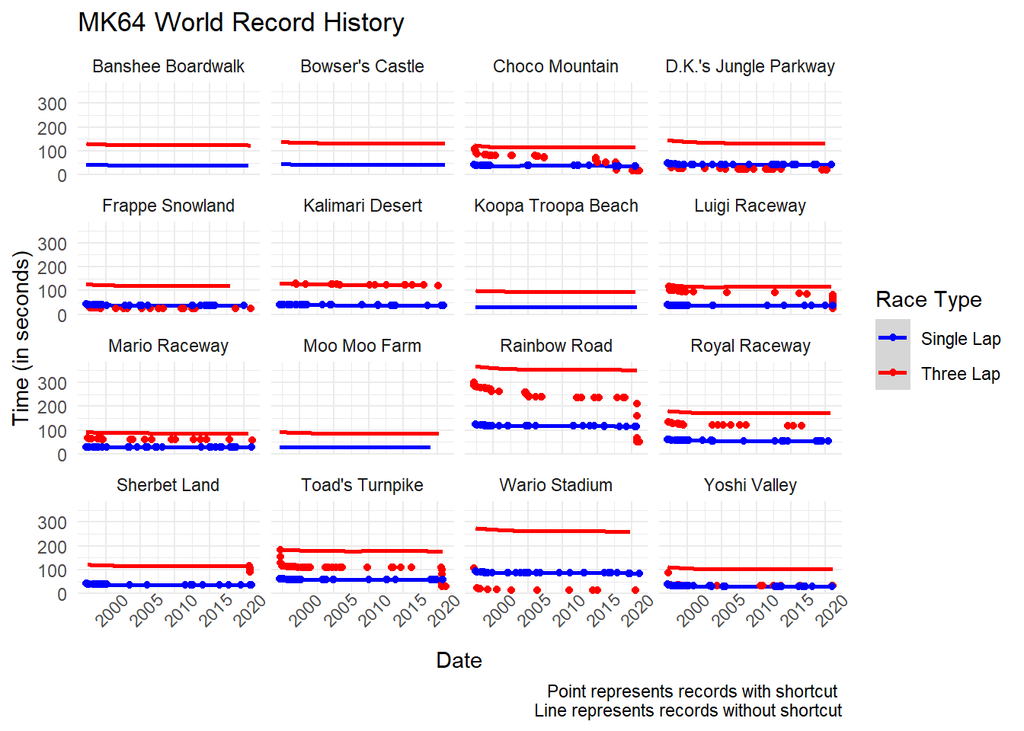

There are two noticeable groups of tracks, those with shortcuts and those without. Records set without shortcuts have a gradual trend while those with shortcuts can have more drastic improvement on time. Shortcuts have less of an impact on single lap records, but there are some three lap records which are faster than single lap, which is suspicious.

#### These tables were created to answer our second question, “What are the current track records?”

MK64: Single Lap Track Records

|  | Race Type | System Played | Date | Time (sec) | Nationality |
| --- | --- | --- | --- | --- | --- |
| Luigi Raceway |  |  |  |  |  |
| Dan | Single Lap | PAL | 2021-01-10 | 37.58 | USA |
| MR | Single Lap | PAL | 2021-02-06 | 37.58 | Germany |
| Moo Moo Farm |  |  |  |  |  |
| abney317 | Single Lap | PAL | 2018-12-29 | 27.80 | USA |
| Koopa Troopa Beach |  |  |  |  |  |
| Dan | Single Lap | PAL | 2020-10-18 | 30.78 | USA |
| Kalimari Desert |  |  |  |  |  |
| Dan | Single Lap | PAL | 2020-11-07 | 38.96 | USA |
| Toad's Turnpike |  |  |  |  |  |
| Dan | Single Lap | PAL | 2020-09-20 | 58.69 | USA |
| Frappe Snowland |  |  |  |  |  |
| Dan | Single Lap | PAL | 2019-12-25 | 38.27 | USA |
| Choco Mountain |  |  |  |  |  |
| MR | Single Lap | PAL | 2020-07-17 | 38.02 | Germany |
| Mario Raceway |  |  |  |  |  |
| Dan | Single Lap | PAL | 2021-01-26 | 27.62 | USA |
| MR | Single Lap | PAL | 2021-02-20 | 27.62 | Germany |
| Wario Stadium |  |  |  |  |  |
| Dan | Single Lap | PAL | 2021-01-26 | 85.82 | USA |
| Sherbet Land |  |  |  |  |  |
| MR | Single Lap | PAL | 2021-02-19 | 37.72 | Germany |
| Royal Raceway |  |  |  |  |  |
| Dan | Single Lap | PAL | 2020-06-11 | 55.50 | USA |
| Bowser's Castle |  |  |  |  |  |
| Dan | Single Lap | PAL | 2021-02-02 | 43.15 | USA |
| D.K.'s Jungle Parkway |  |  |  |  |  |
| Dan | Single Lap | PAL | 2020-10-26 | 42.04 | USA |
| Yoshi Valley |  |  |  |  |  |
| MR | Single Lap | PAL | 2018-01-18 | 31.25 | Germany |
| Dan | Single Lap | PAL | 2021-01-01 | 31.25 | USA |
| Banshee Boardwalk |  |  |  |  |  |
| Dan | Single Lap | PAL | 2020-06-11 | 40.78 | USA |
| MR | Single Lap | PAL | 2020-08-21 | 40.78 | Germany |
| Rainbow Road |  |  |  |  |  |
| MR | Single Lap | PAL | 2020-09-04 | 116.35 | Germany |

MK64: Three Lap Track Records

|  | Race Type | System Played | Date | Time (sec) | Nationality |
| --- | --- | --- | --- | --- | --- |
| Luigi Raceway |  |  |  |  |  |
| abney317 | Three Lap | NTSC | 2021-02-11 | 25.30 | USA |
| Moo Moo Farm |  |  |  |  |  |
| MR | Three Lap | PAL | 2020-02-18 | 85.93 | Germany |
| Koopa Troopa Beach |  |  |  |  |  |
| Dan | Three Lap | PAL | 2020-07-13 | 95.25 | USA |
| Kalimari Desert |  |  |  |  |  |
| abney317 | Three Lap | PAL | 2020-01-20 | 121.92 | USA |
| Toad's Turnpike |  |  |  |  |  |
| iMathII | Three Lap | NTSC | 2021-02-14 | 30.31 | Canada |
| Frappe Snowland |  |  |  |  |  |
| abney317 | Three Lap | PAL | 2021-01-08 | 23.61 | USA |
| Choco Mountain |  |  |  |  |  |
| abney317 | Three Lap | NTSC | 2021-02-03 | 17.29 | USA |
| Mario Raceway |  |  |  |  |  |
| abney317 | Three Lap | PAL | 2021-02-25 | 58.49 | USA |
| Wario Stadium |  |  |  |  |  |
| VAJ | Three Lap | NTSC | 2020-07-30 | 14.59 | Netherlands |
| Sherbet Land |  |  |  |  |  |
| abney317 | Three Lap | NTSC | 2020-11-13 | 91.65 | USA |
| Royal Raceway |  |  |  |  |  |
| abney317 | Three Lap | PAL | 2016-07-31 | 119.49 | USA |
| Bowser's Castle |  |  |  |  |  |
| Dan | Three Lap | PAL | 2021-02-02 | 132.00 | USA |
| D.K.'s Jungle Parkway |  |  |  |  |  |
| abney317 | Three Lap | PAL | 2020-02-25 | 21.35 | USA |
| Yoshi Valley |  |  |  |  |  |
| abney317 | Three Lap | NTSC | 2020-12-03 | 33.35 | USA |
| VAJ | Three Lap | PAL | 2021-01-21 | 33.35 | Netherlands |
| Banshee Boardwalk |  |  |  |  |  |
| MR | Three Lap | PAL | 2021-01-15 | 124.09 | Germany |
| Rainbow Road |  |  |  |  |  |
| abney317 | Three Lap | NTSC | 2021-02-07 | 50.38 | USA |

The current track records are listed in the table. Americans and Germans hold a lot of the records and there’s more diversity based on nationality in the complete race records. Most records were made in 2020 and 2021 but there are a few that still hold from 2018 and 2016 and have been tied at best. Phase Alternating Line (PAL) system appears to be favored in single lap records while there’s a more even ratio of PAL to National Television System Committee (NTSC) in the complete race records.

#### These data visualizations were created to answer our third question, “How much has the time improved for each track?”

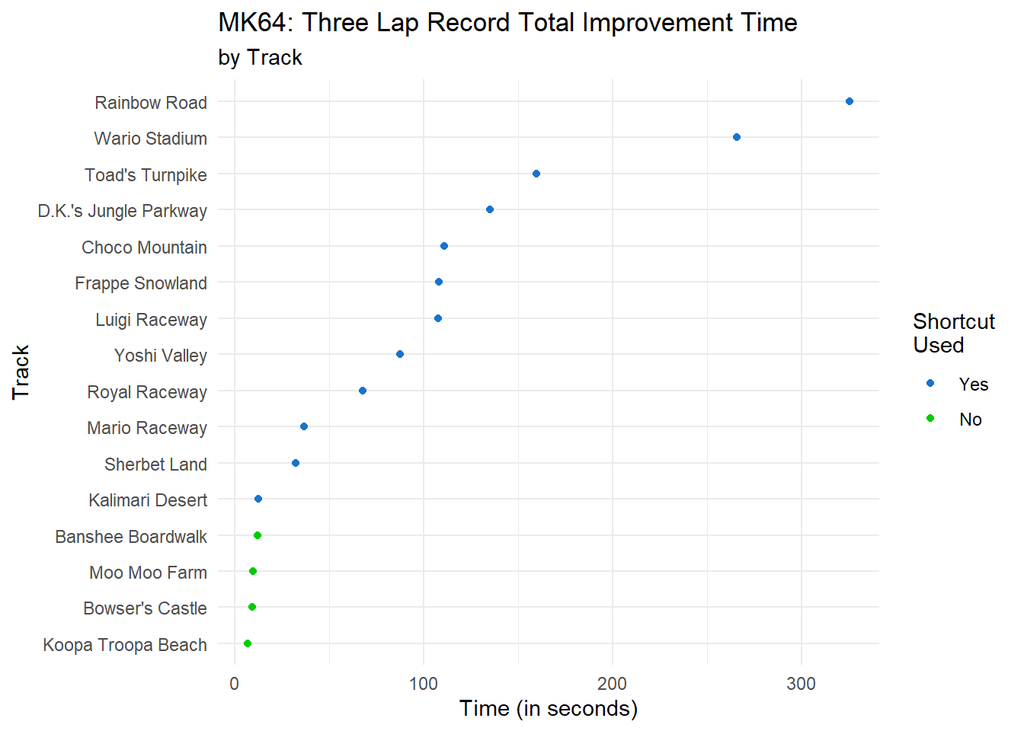

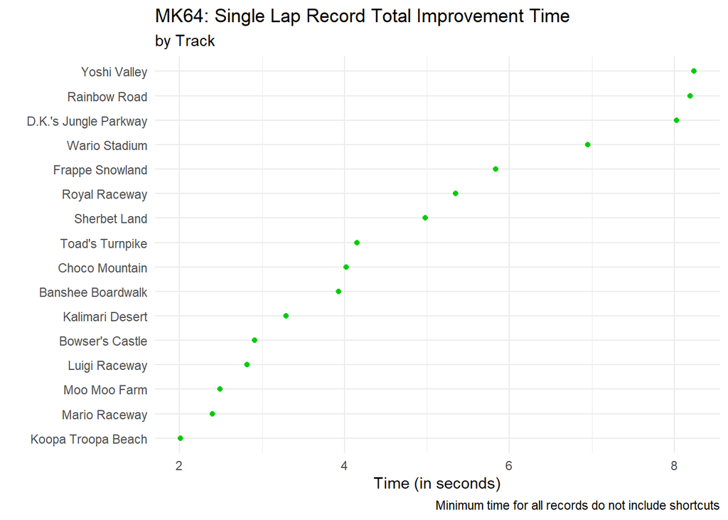

#### These data visualization was created to answer our fourth question, “How much time were the longest held records beat by?”

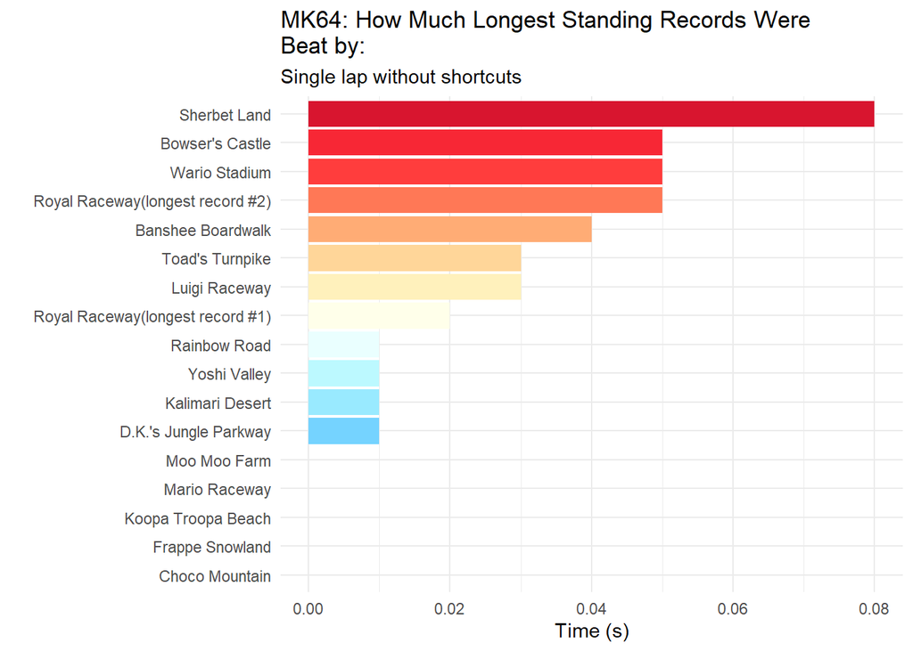

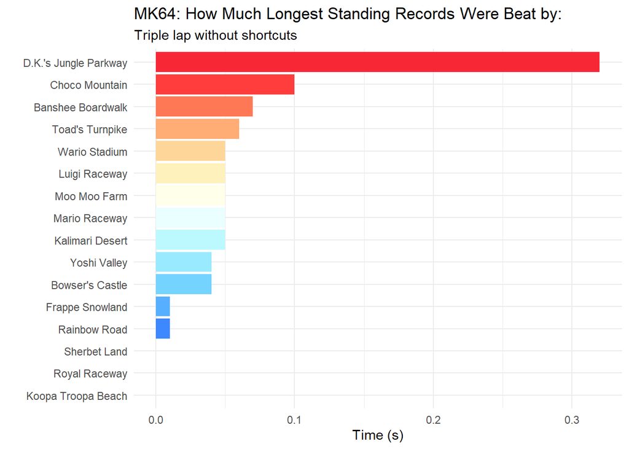

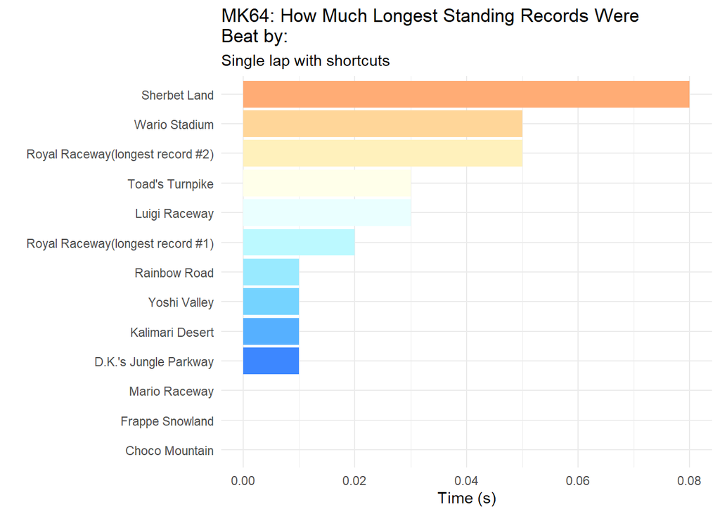

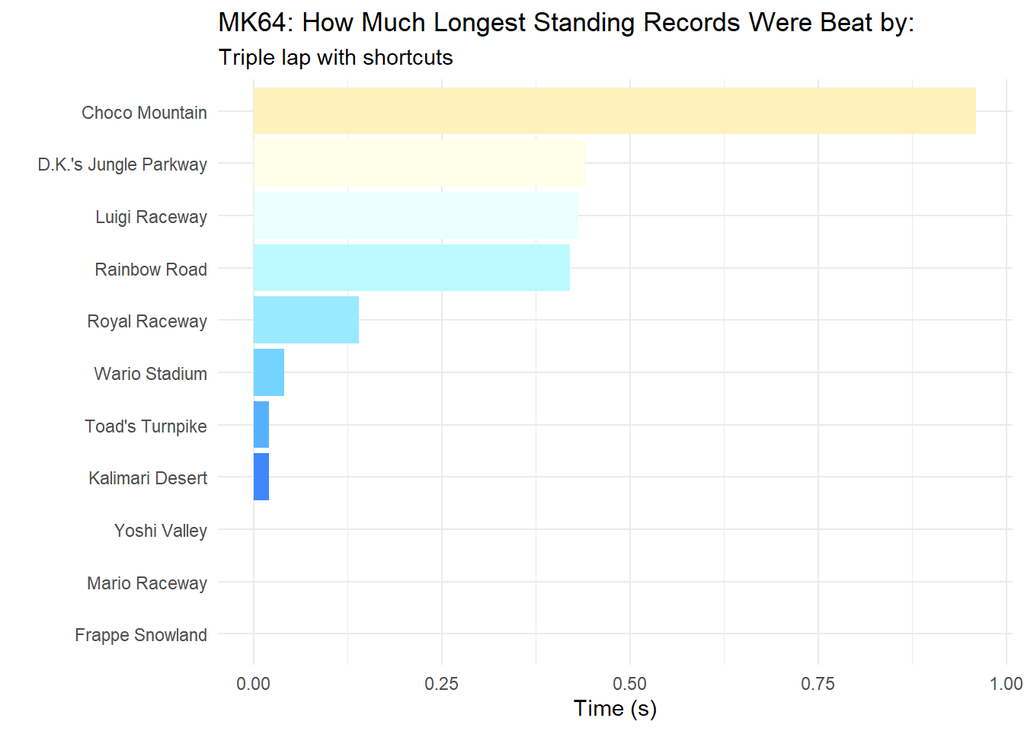

### 3. Conclusions and Future Work

#### a.

1. What are the overall trends of the records?

While records without shortcuts have a more gradual record history, some of the records with shortcuts are suspicious since a three lap record shouldn’t be less than a single lap.

2. What are the current track records?

Most track records were relatively new and single lap records seem to favor the PAL system. Further investigation is needed to see if this is consistent with the rest of the record data, and if so, what’s the reasoning for it.

3. How much has the time improved for each track?

4. How much time were the longest held records beat by?

#### b.

Another question we would like to answer is, “Are PAL systems are preferred for single lap records and if so, why?” To investigate this further we would filter the records data set by single laps and look at the system to see if the trend holds. If it does, then further investigation into the data source, Mario Kart World Records, may be necessary. If the trend does not hold, I would look to see if there are patterns with single laps played on PAL systems with any other variables by filtering the records data set and for single lap records played on PAL systems and looking for any trends in the data.

While the data sets are somewhat limited in variables, it would be interesting to investigate, “How much time shortcuts save” While we cannot currently do with shortcuts being a Boolean, if the data did exist, perhaps by some determined or seriously bored person recording this based on the record videos on Mario Kart World Records, it would be interesting to create a box plot for each track depicting the time shortcuts saved. Including a semi-transparent jittered scatterplot on top of them could help give a better sense of the individual data points.

### 4. References:

##### Claus, B. (2021, May 25). Mario Kart 64 World Records. GitHub. https://github.com/rfordatascience/tidytuesday/blob/master/data/2021/2021-05-25/readme.md

##### Mario Kart 64 Players’ Page. (n.d.). Www.mariokart64.com. Retrieved December 6, 2022, from https://www.mariokart64.com/mk64/

##### Mario Kart World Records. (n.d.). Mkwrs.com. Retrieved December 6, 2022, from https://mkwrs.com/

##### MK64 WR History. (n.d.). Mkwrs.com. Retrieved December 6, 2022, from https://mkwrs.com/mk64/

##### Nobles, B. (n.d.). Best Mario Kart 64 Characters, All Ranked (Using Math!). FandomSpot. Retrieved December 8, 2022, from https://www.fandomspot.com/best-mario-kart-64-characters/